# Praca domowa 2

## Zadanie 5

Czy jest zależnośc pomiędzy wiekiem klientów a ich średnim rocznym saldzie w euro w podziale na stopień wykształcenia?

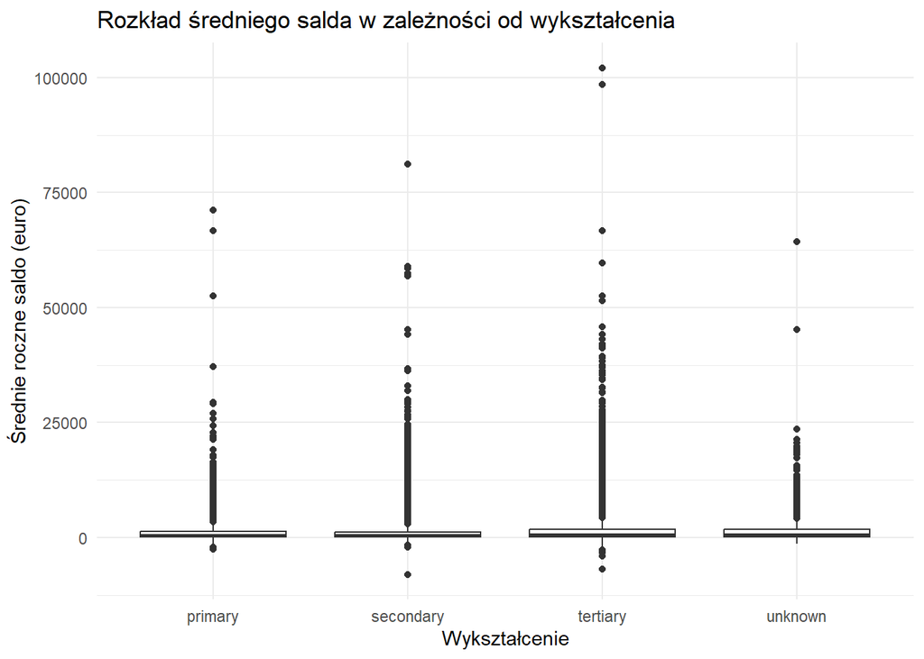

```r
zadanie5.1 <- df %>% group_by(age, education) %>% summarise(srednie_saldo = mean(balance, na.rm = TRUE), liczba = n())
zadanie5.podstawowe <- zadanie5.1 %>% filter(education == "primary")
zadanie5.wyzsze <- zadanie5.1 %>% filter(education == "tertiary")
zadanie5.srednie <- zadanie5.1 %>% filter(education == "secondary")
zadanie5.nieznane <- zadanie5.1 %>% filter(education == "unknown")


ggplot(df, aes(x = education, y = balance)) + geom_boxplot() +
  labs(title = "Rozkład średniego salda w zależności od wykształcenia",
       x = "Wykształcenie", y = "Średnie roczne saldo (euro)") +
  theme_minimal()
```

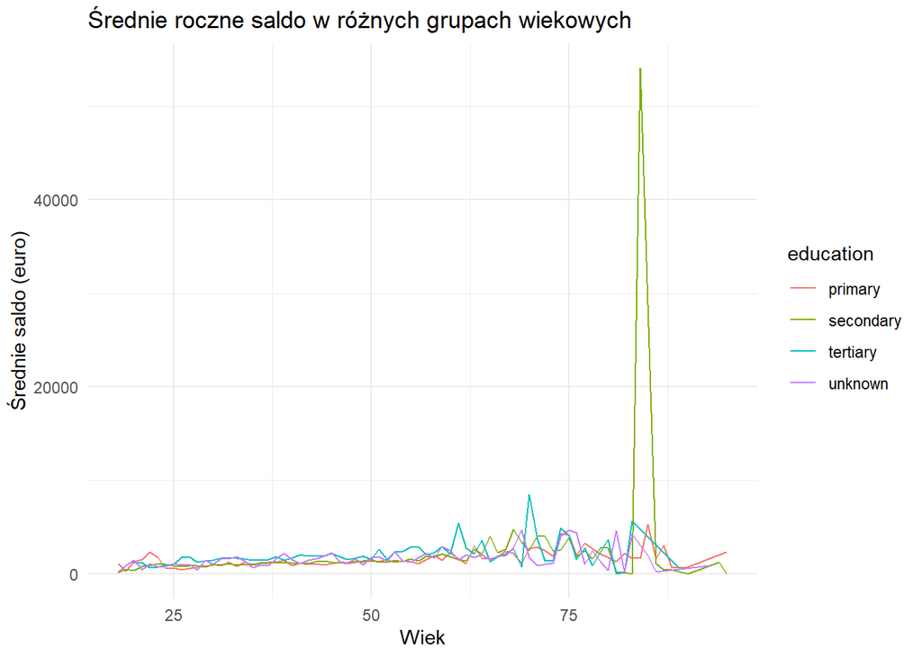

```r
ggplot(zadanie5.1, aes(x = age, y = srednie_saldo, color = education)) +
  geom_line() +
  labs(title = "Średnie roczne saldo w różnych grupach wiekowych",
       x = "Wiek", y = "Średnie saldo (euro)") +
  theme_minimal()
```

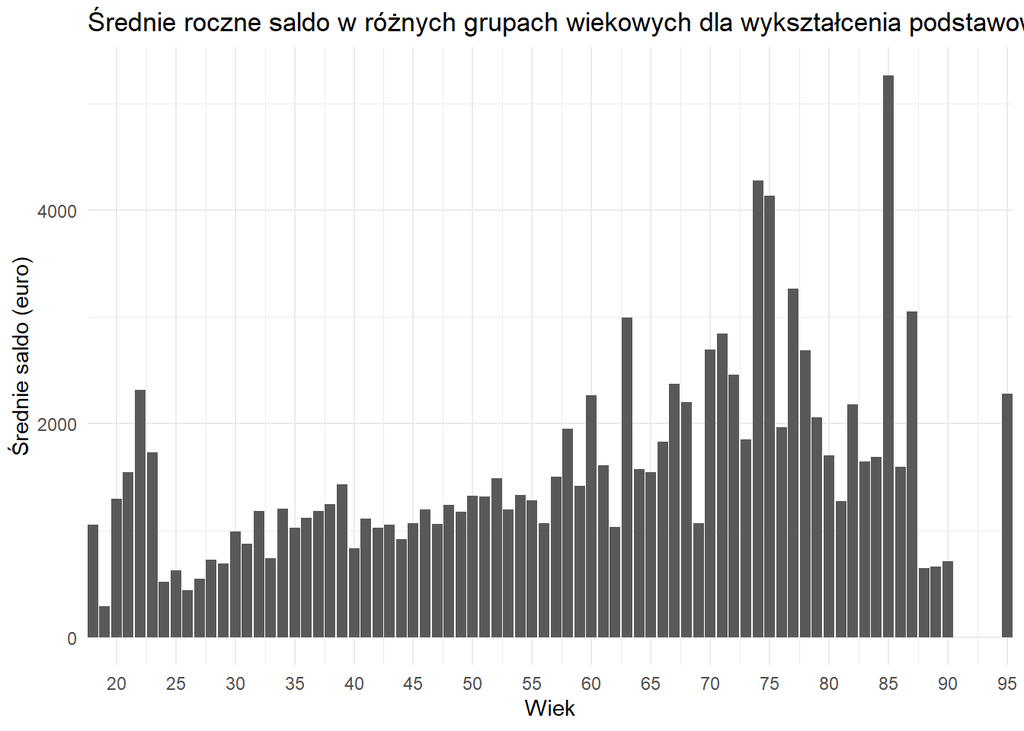

```r
ggplot(zadanie5.podstawowe, aes(x = age, y = srednie_saldo)) +
  geom_col() +
  labs(title = "Średnie roczne saldo w różnych grupach wiekowych dla wykształcenia podstawowego",
       x = "Wiek", y = "Średnie saldo (euro)") +
  theme_minimal() + theme(plot.title = element_text(size = 13)) +
  scale_x_continuous(expand = c(0, 0), breaks = seq(0, 95, by = 5))
```

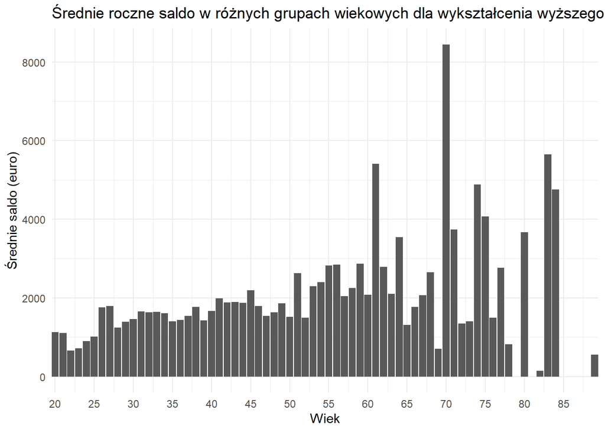

```r
ggplot(zadanie5.wyzsze, aes(x = age, y = srednie_saldo)) +
  geom_col() +
  labs(title = "Średnie roczne saldo w różnych grupach wiekowych dla wykształcenia wyższego",
       x = "Wiek", y = "Średnie saldo (euro)") +
  theme_minimal() + theme(plot.title = element_text(size = 13)) +
  scale_x_continuous(expand = c(0, 0), breaks = seq(0, 95, by = 5))
```

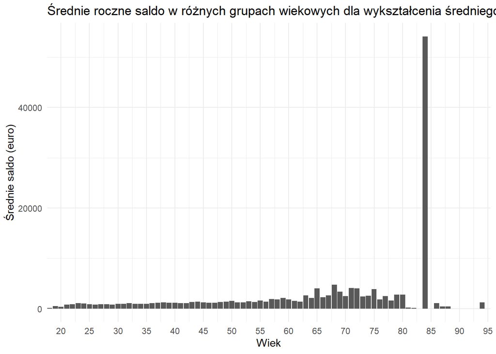

```r
ggplot(zadanie5.srednie, aes(x = age, y = srednie_saldo)) +
  geom_col() +
  labs(title = "Średnie roczne saldo w różnych grupach wiekowych dla wykształcenia średniego",
       x = "Wiek", y = "Średnie saldo (euro)") +
  theme_minimal() + theme(plot.title = element_text(size = 13)) +
  scale_x_continuous(expand = c(0, 0), breaks = seq(0, 95, by = 5))
```

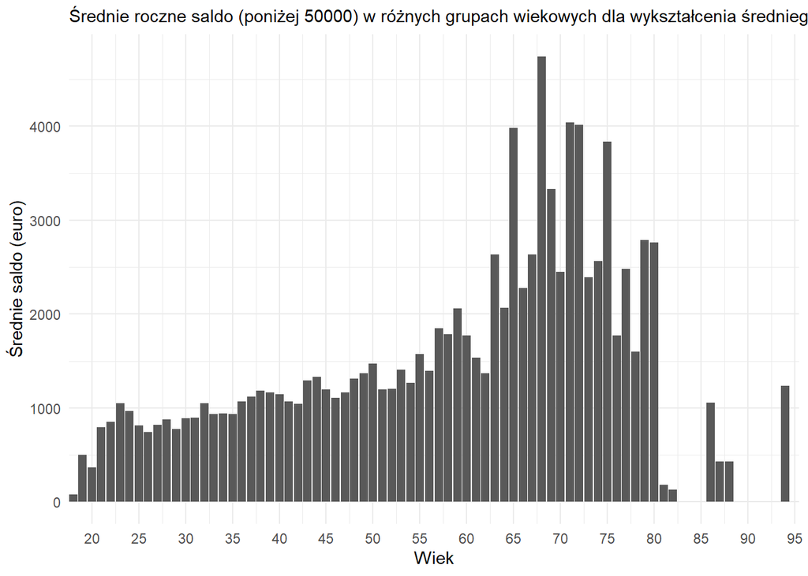

```r
ggplot(zadanie5.srednie %>%  filter(srednie_saldo < 50000), aes(x = age, y = srednie_saldo)) +
  geom_col() +
  labs(title = "Średnie roczne saldo (poniżej 50000) w różnych grupach wiekowych dla wykształcenia średniego",
       x = "Wiek", y = "Średnie saldo (euro)") +
  theme_minimal() + theme(plot.title = element_text(size = 11)) +
  scale_x_continuous(expand = c(0, 0), breaks = seq(0, 95, by = 5))
```

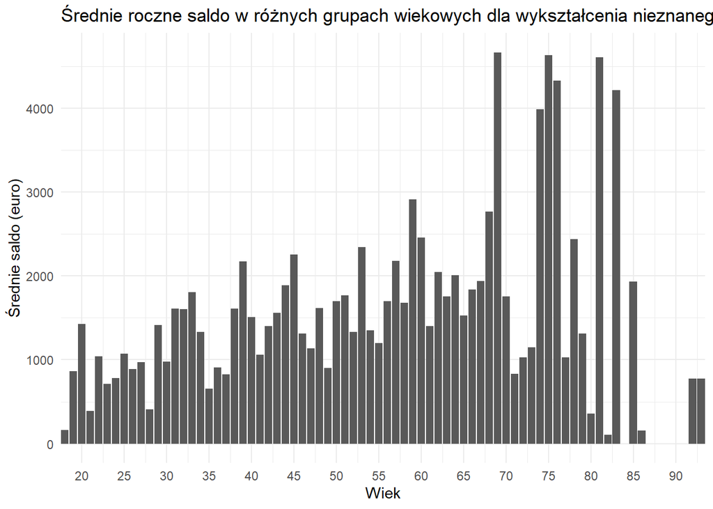

```r
ggplot(zadanie5.nieznane, aes(x = age, y = srednie_saldo)) +
  geom_col() +
  labs(title = "Średnie roczne saldo w różnych grupach wiekowych dla wykształcenia nieznanego",
       x = "Wiek", y = "Średnie saldo (euro)") +
  theme_minimal() + theme(plot.title = element_text(size = 13)) +
  scale_x_continuous(expand = c(0, 0), breaks = seq(0, 95, by = 5))
```

**Komentarz:**

Zarówno dla wykształcenia podstawowego jak i nieznanego saldo jest mniej więcej podobne, zwiększa się wraz z wiekiem przyjmując najwyższe wartości dla grup wiekowych 65-85 lat. Dla wykształcenia śedniego jest to podobny trent, lecz zwiększa się bardziej stabilnie, bez skoków dla różnych grup wiekowych, osiągając swój pik dla 64-75 lat, występuje również obserwacją odstająca, która jest blisko 10 ktornie większa od pzostałych najwyższech średnich sald dla tego rodzaju wykształcenia. Dla wykształcenia wyższego występuje dla lat 20-30 niewilki wzrost, a następnie średnie saldo jest na bliskim sobie rónym poziomie aż do grupy wiekowej 60 lat, gdzie widzimy, że w kolejnych grupach wiekowych saldo jest duże, bądź małe, prawie nie przyjmuje wartości pośrednich. W każdej w próbek jest cięzko stwierdzić jak wygląda sytuacja dla osób starszych, powyżej 75 lat, ponieważ występują braki danych i znaczące wachania wyników.